# Supervised Programing for Customer Churn

Chloé Winters

2025-11-06

# 1 Introduction

This assignment will look at customer churn data from several telecommunication companies. The goal is to determine what makes a customer more likely or less likely to churn so these companies can understand how to best retain customers. Supervised programming techniques qill be utelized in the model building process, followed by ROC and Bagging AUC analysis to ultimately determine the final model.

# 2 Materials

## 2.1 Data Set

This data set is a small portion of a telecommunication companies customer data. The data set was created to investigate service quality and improve customer retention. There are 1,000 observations in the data set and 14 variables which are described below. While the categorical variables do get recategorized as factor variables for analysis purposes we will describe the data set as it originally stands.

```r
url ="https://chloewinters79.github.io/STA551/Data/churn_output.csv"
churn = read.csv(url, header = TRUE)

cat_vars <- c("Sex", "Marital_Status", "Phone_service", "International_plan",
              "Voice_mail_plan", "Multiple_line", "Internet_service",
              "Technical_support", "Streaming_Videos", "Agreement_period", "Churn")

churn[cat_vars] <- lapply(churn[cat_vars], factor)
```

1. Sex: (cat) customer’s gender
2. Marital_Status: (cat) marital status of the customer
3. Term: (num) duration of the customer’s term in months
4. Phone_service: (cat) indicates whether the customer has phone service (Yes = has phone service; No = does not have phone service)
5. International_plan: (cat) indicates whether the customer has an international calling plan (Yes = has international plan; No = does not have international plan)
6. Voice_mail_plan: (cat) indicates whether the customer has a voice mail plan (Yes = has voice mail plan; No = does not have voice mail plan)
7. Multiple_line: (cat) indicates whether the customer has multiple phone lines (Yes = has multiple lines; No = does not have multiple lines; No phone = does not have phone service)
8. Internet_service: (cat) type of internet service the customer has (Cable, Fibre optic, DSL, or No internet)
9. Technical_support: (cat) indicates whether the customer has technical support (Yes = has technical support; No = does not have technical support; No internet = does not have internet service)
10. Streaming_Videos: (cat) indicates whether the customer has streaming video service (Yes = has streaming service; No = does not have streaming service; No internet = does not have internet service)
11. Agreement_period: (cat) type of contract agreement (Monthly, One year, or Two year contract)
12. Monthly_Charges: (num) monthly service charges billed to the customer
13. Total_Charges: (num) total charges incurred by the customer over their service term
14. Churn: (cat) indicates customer churn status (Yes = customer churned; No = customer retained)

## 2.2 Exploratory Data Analysis

Now that we are familiar with our starting data set we need to go through EDA and data cleaning so the final working data set meets the requirements of the assignment.

First we start by checking for missing values, as shown in the output none of the variables have any missing observations which means we do not need to do any imputation or removing of observations for too many missing values.

```r
# Check for Missing Values
colSums(is.na(churn))
```

```
               Sex     Marital_Status               Term      Phone_service
                 0                  0                  0                  0
International_plan    Voice_mail_plan      Multiple_line   Internet_service
                 0                  0                  0                  0
 Technical_support   Streaming_Videos   Agreement_period    Monthly_Charges
                 0                  0                  0                  0
     Total_Charges              Churn
                 0                  0
```

The next step is to make sure all the variables are properly categorized for our analysis, so the approportiate variables are being converted to factor variables to make for an easier analysis of these variables when we go into our model building.

```r
# Convert Appropriate Variables to Factors
cat_vars <- c("Sex", "Marital_Status", "Phone_service", "International_plan",
              "Voice_mail_plan", "Multiple_line", "Internet_service",
              "Technical_support", "Streaming_Videos", "Agreement_period", "Churn")

churn[cat_vars] <- lapply(churn[cat_vars], factor)
```

```r
# Summary Statistics
# For categorical variables
for (v in cat_vars) {
  print(v)
  print(table(churn[[v]]))
}
```

```
[1] "Sex"

Female   Male
   486    514
[1] "Marital_Status"

Married  Single
    735     265
[1] "Phone_service"

 No Yes
 89 911
[1] "International_plan"

 No Yes
429 571
[1] "Voice_mail_plan"

 No Yes
442 558
[1] "Multiple_line"

       No No phone        Yes
      467        89       444
[1] "Internet_service"

      Cable         DSL Fiber optic No Internet
        171         280         341         208
[1] "Technical_support"

          No No internet           Yes
         476          208          316
[1] "Streaming_Videos"

          No No internet           Yes
         382          208          410
[1] "Agreement_period"

 Monthly contract One year contract Two year contract
              539               208               253
[1] "Churn"

 No Yes
741 259
```

```r
# For numerical variables
num_vars <- c("Term", "Monthly_Charges", "Total_Charges")
summary(churn[num_vars])
```

```
      Term      Monthly_Charges  Total_Charges
 Min.   : 0.0   Min.   : 18.95   Min.   :   5.0
 1st Qu.: 8.0   1st Qu.: 40.16   1st Qu.: 334.8
 Median :30.0   Median : 74.72   Median :1442.3
 Mean   :32.8   Mean   : 66.64   Mean   :2351.6
 3rd Qu.:57.0   3rd Qu.: 90.88   3rd Qu.:4016.8
 Max.   :72.0   Max.   :116.25   Max.   :8476.5
```

```r
# Fix International
churn$International_plan <- ifelse(tolower(churn$International_plan) == "yes", "Yes",
                            ifelse(tolower(churn$International_plan) == "no", "No",
                                   churn$International_plan))

churn$International_plan <- factor(churn$International_plan)
```

Looking at our binary variable churn, we see a skew towards No, which means a majority of customers are not churning which is ideal for the company. Considering the size of the data set we are working with the lower amount of yes for churns is not concering because despite being almost a 3:1 ratio of no to yes we still have plenty of data to work with and we should not be concerened with this impacting our analysis.

```r
# Explore Target Variable (Churn)
prop.table(table(churn$Churn))
```

```
   No   Yes
0.741 0.259
```

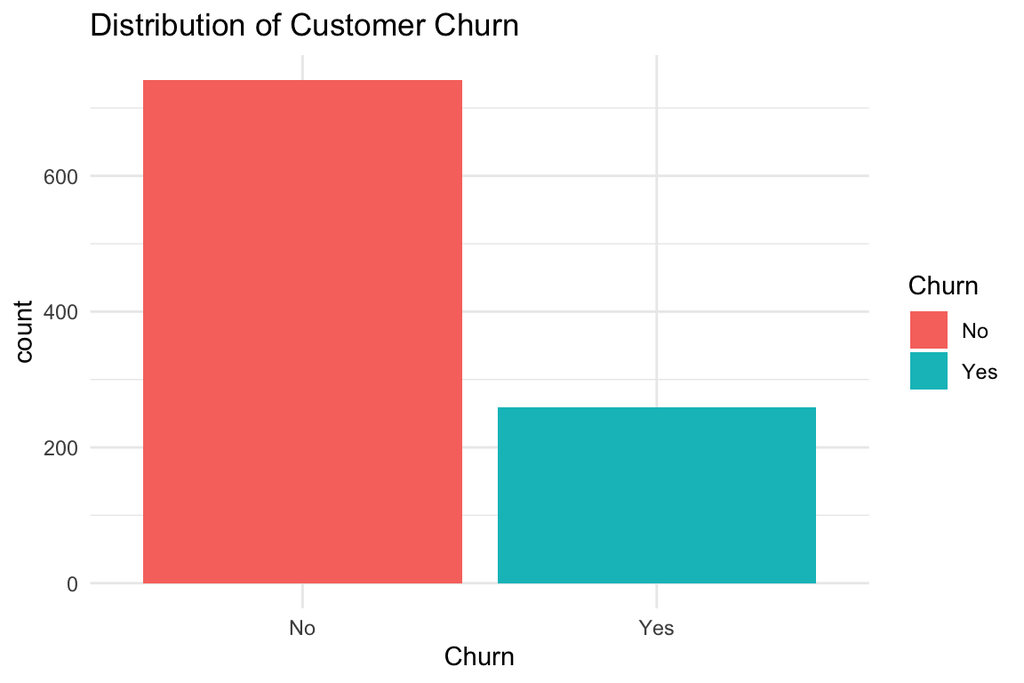

```r
ggplot(churn, aes(x = Churn, fill = Churn)) +
  geom_bar() +
  labs(title = "Distribution of Customer Churn") +
  theme_minimal()
```

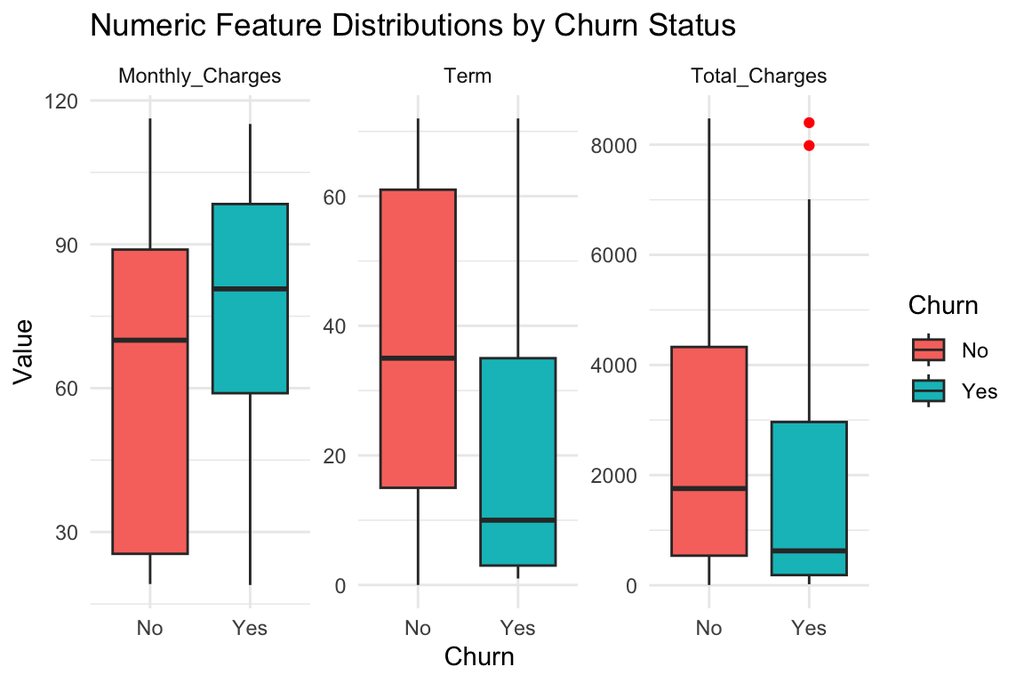

```r
# Explore Relationships Between Features and Churn

# Numeric vs Target
churn %>%
  dplyr::select(all_of(num_vars), Churn) %>%
  pivot_longer(cols = all_of(num_vars), names_to = "Variable", values_to = "Value") %>%
  ggplot(aes(x = Churn, y = Value, fill = Churn)) +
  geom_boxplot(outlier.color = "red") +
  facet_wrap(~Variable, scales = "free") +
  labs(title = "Numeric Feature Distributions by Churn Status") +
  theme_minimal()
```

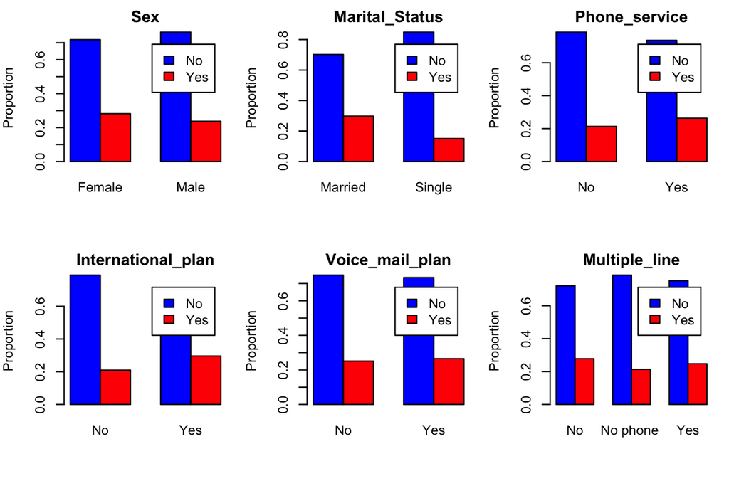

```r
# Select categorical variables excluding Churn
cat_vars_plot <- cat_vars[-length(cat_vars)]

# Set up 3x3 grid
par(mfrow = c(2, 3), mar = c(5, 4, 2, 1))

for (v in cat_vars_plot) {
  counts <- table(churn[[v]], churn$Churn)
  prop <- prop.table(counts, 1)  # row proportions
  barplot(t(prop), col = c("blue", "red"), beside = TRUE,
          main = v, ylab = "Proportion", legend.text = TRUE)
}
```

[figure not shown]

```r
# Reset layout
par(mfrow = c(1, 1))
```

Looking at the correlation between the numerical variables there seems to be high correlation between term and total charges, and moderate correaltion between total charges and monthly charges. These do make sense in the context of the data since the longer a customer is with the company the more terms they will have and thus the more they will have paid overall. So this correlation while high does make sense contextually and does not appear to me a major cause for concern at this moment just something to keep in mind.

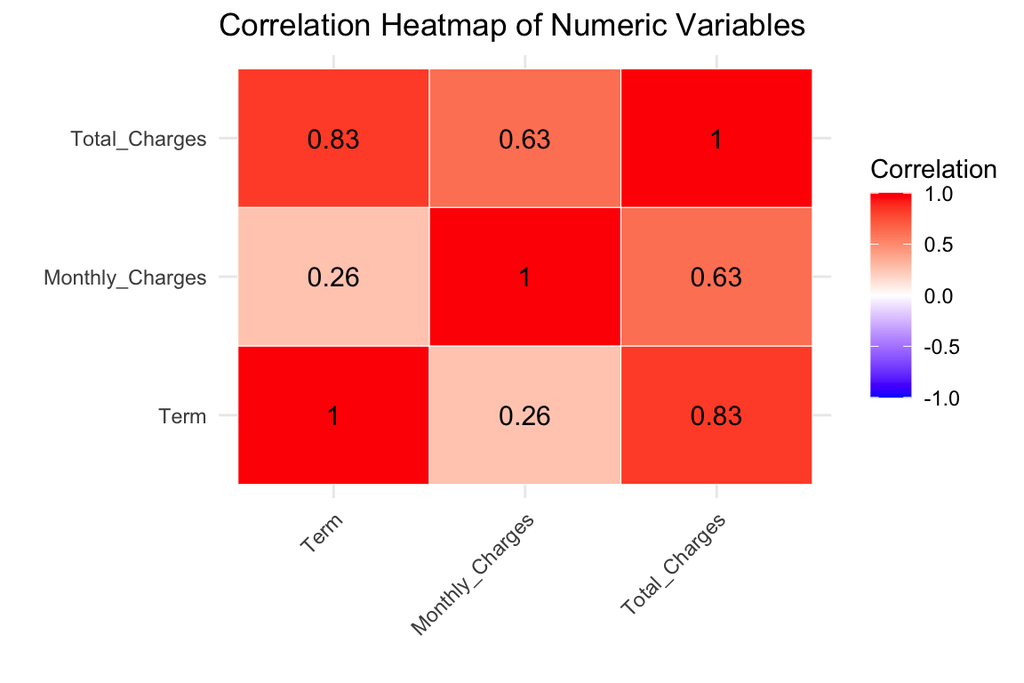

```r
num_data <- churn %>%
  select(all_of(num_vars)) %>%
  drop_na()


# Compute correlation matrix
cor_mat <- cor(num_data)

# Melt correlation matrix for ggplot
cor_melt <- melt(cor_mat)

# Heatmap
ggplot(cor_melt, aes(x = Var1, y = Var2, fill = value)) +
  geom_tile(color = "white") +
  scale_fill_gradient2(low = "blue", high = "red", mid = "white",
                       midpoint = 0, limit = c(-1,1), space = "Lab",
                       name="Correlation") +
  geom_text(aes(label = round(value, 2)), color = "black", size = 4) +
  theme_minimal() +
  theme(axis.text.x = element_text(angle = 45, vjust = 1, hjust = 1)) +
  labs(title = "Correlation Heatmap of Numeric Variables", x = "", y = "")
```

Now that all the exploratory data analysis has been conducted and there does not appear to be anything drastically concerning that needs to undergo specific transformations in this moment we can move onto our analysis and starting with our question.

# 3 Methodolgy & Analysis

In this assignment we are going to be looking into which variables help predict the likelihood of a customer churning. This assignment will cover three different types of models, logistic, perceptron, and decision tree modeling. The project will utilize a training and testing data set along with bagging.

## 3.1 Logistic Models

First we are going to start by building our logistic models, we are going to build three models and when we have all our models we are going to do some ROC analysis to pick the best models. For the three models we are going to do a full, reduced, and stepwise model and give a brief interpretation of them.

```r
# Split data into training and testing
set.seed(123)
train_index <- sample(1:nrow(churn), 0.7 * nrow(churn))
train_data <- churn[train_index, ]
test_data <- churn[-train_index, ]

# Full logistic model including all variables
fullModel <- glm(Churn ~ Sex + Marital_Status + Term + Phone_service + International_plan +
                   Voice_mail_plan + Multiple_line + Internet_service + Technical_support +
                   Streaming_Videos + Agreement_period + Monthly_Charges + Total_Charges,
                 data = train_data, family = binomial)

summary(fullModel)
```

```
Call:
glm(formula = Churn ~ Sex + Marital_Status + Term + Phone_service +
    International_plan + Voice_mail_plan + Multiple_line + Internet_service +
    Technical_support + Streaming_Videos + Agreement_period +
    Monthly_Charges + Total_Charges, family = binomial, data = train_data)

Coefficients: (3 not defined because of singularities)
                                    Estimate Std. Error z value Pr(>|z|)
(Intercept)                        0.3437542  1.0826865   0.318 0.750863
SexMale                           -0.0606378  0.2143552  -0.283 0.777265
Marital_StatusSingle               0.0215681  0.4431041   0.049 0.961178
Term                              -0.0755545  0.0203023  -3.721 0.000198 ***
Phone_serviceYes                   0.0049314  0.6449226   0.008 0.993899
International_planYes              0.1005081  0.2608868   0.385 0.700048
Voice_mail_planYes                -0.1599207  0.2177671  -0.734 0.462726
Multiple_lineNo phone                     NA         NA      NA       NA
Multiple_lineYes                  -0.1588082  0.2612356  -0.608 0.543246
Internet_serviceDSL               -0.5316876  0.4725579  -1.125 0.260535
Internet_serviceFiber optic       -0.1704813  0.2768196  -0.616 0.537989
Internet_serviceNo Internet       -1.9314335  0.9331285  -2.070 0.038467 *
Technical_supportNo internet              NA         NA      NA       NA
Technical_supportYes              -0.4083748  0.2781549  -1.468 0.142062
Streaming_VideosNo internet               NA         NA      NA       NA
Streaming_VideosYes                0.3112777  0.3466962   0.898 0.369271
Agreement_periodOne year contract -1.6102100  0.3742255  -4.303 1.69e-05 ***
Agreement_periodTwo year contract -2.1326236  0.5178134  -4.119 3.81e-05 ***
Monthly_Charges                    0.0029681  0.0164428   0.181 0.856753
Total_Charges                      0.0006610  0.0002203   3.000 0.002696 **
---
Signif. codes:  0 '***' 0.001 '**' 0.01 '*' 0.05 '.' 0.1 ' ' 1

(Dispersion parameter for binomial family taken to be 1)

    Null deviance: 782.84  on 699  degrees of freedom
Residual deviance: 571.58  on 683  degrees of freedom
AIC: 605.58

Number of Fisher Scoring iterations: 6
```

```r
# Reduced logistic model
reducedModel <- glm(Churn ~ Term + Internet_service + Agreement_period + Total_Charges,
                    data = train_data, family = binomial)
summary(reducedModel)
```

```
Call:
glm(formula = Churn ~ Term + Internet_service + Agreement_period +
    Total_Charges, family = binomial, data = train_data)

Coefficients:
                                    Estimate Std. Error z value Pr(>|z|)
(Intercept)                        0.4884859  0.2608144   1.873 0.061079 .
Term                              -0.0764982  0.0187508  -4.080 4.51e-05 ***
Internet_serviceDSL               -0.5861887  0.3179624  -1.844 0.065245 .
Internet_serviceFiber optic       -0.1125347  0.2651529  -0.424 0.671264
Internet_serviceNo Internet       -2.0459393  0.4580323  -4.467 7.94e-06 ***
Agreement_periodOne year contract -1.7066788  0.3624799  -4.708 2.50e-06 ***
Agreement_periodTwo year contract -2.2908746  0.4988898  -4.592 4.39e-06 ***
Total_Charges                      0.0006786  0.0001919   3.536 0.000406 ***
---
Signif. codes:  0 '***' 0.001 '**' 0.01 '*' 0.05 '.' 0.1 ' ' 1

(Dispersion parameter for binomial family taken to be 1)

    Null deviance: 782.84  on 699  degrees of freedom
Residual deviance: 576.85  on 692  degrees of freedom
AIC: 592.85

Number of Fisher Scoring iterations: 6
```

Finally, we have our stepwise model, this model included Term, Technical_support, Agreement_period, Monthly_Charges, and Total_Charges. Significant predictors were Term, Technical_supportNo internet, Agreement_periodOne year contract, Agreement_periodTwo year contract, and Total_Charges. Somewhat significant predictors included Technical_supportYes and Monthly_Charges. The model suggests that shorter terms, lack of technical support, shorter agreement periods, and higher total charges increase the likelihood of churn, while other variables have little effect.

```r
# Stepwise logistic model (both directions)
stepModel <- stepAIC(fullModel, direction = "both", trace = FALSE)
summary(stepModel)
```

```
Call:
glm(formula = Churn ~ Term + Technical_support + Agreement_period +
    Monthly_Charges + Total_Charges, family = binomial, data = train_data)

Coefficients:
                                    Estimate Std. Error z value Pr(>|z|)
(Intercept)                       -0.5002374  0.5020732  -0.996 0.319083
Term                              -0.0758036  0.0199369  -3.802 0.000143 ***
Technical_supportNo internet      -1.3090452  0.5147591  -2.543 0.010990 *
Technical_supportYes              -0.4513076  0.2581836  -1.748 0.080462 .
Agreement_periodOne year contract -1.6119374  0.3696002  -4.361 1.29e-05 ***
Agreement_periodTwo year contract -2.1458239  0.5081868  -4.223 2.42e-05 ***
Monthly_Charges                    0.0118295  0.0067427   1.754 0.079358 .
Total_Charges                      0.0006424  0.0002156   2.980 0.002884 **
---
Signif. codes:  0 '***' 0.001 '**' 0.01 '*' 0.05 '.' 0.1 ' ' 1

(Dispersion parameter for binomial family taken to be 1)

    Null deviance: 782.84  on 699  degrees of freedom
Residual deviance: 574.84  on 692  degrees of freedom
AIC: 590.84

Number of Fisher Scoring iterations: 6
```

## 3.2 Peceptron Models

Moving onto our peceptron model we will be looking at two models since peceptron does not have the natural ability to do a stepwise regression process like a logistic regression model would. Thus, for this analysis there will be a full and reduced model created. Before that happens though, the numeric variables need to undergo some scaling so they can be utilized properly in the peceptron models.

```r
# Scale numeric variables
churn_nn <- churn %>%
  mutate(
    Term_scale = (Term - min(Term)) / (max(Term) - min(Term)),
    Monthly_Charges_scale = (Monthly_Charges - min(Monthly_Charges)) /
                            (max(Monthly_Charges) - min(Monthly_Charges)),
    Total_Charges_scale = (Total_Charges - min(Total_Charges)) /
                          (max(Total_Charges) - min(Total_Charges))
  )

# Drop original numeric columns
churn_nn <- churn_nn[, !(names(churn_nn) %in% c("Term", "Monthly_Charges", "Total_Charges"))]

# Convert Churn to numeric
churn_nn$Churn_num <- ifelse(churn_nn$Churn == "Yes", 1, 0)

# Convert categorical variables to dummy variables
cat_vars <- setdiff(colnames(churn_nn), c("Term_scale", "Monthly_Charges_scale", "Total_Charges_scale", "Churn", "Churn_num"))

churn_nn_dummy <- churn_nn %>%
  mutate(across(all_of(cat_vars), as.factor)) %>%
  model.matrix(~ . - 1, data = .) %>%
  as.data.frame()

# Clean column names
colnames(churn_nn_dummy) <- make.names(colnames(churn_nn_dummy))

# Add numeric target back
churn_nn_dummy$Churn_num <- churn_nn$Churn_num
```

```r
# Full Model

NN_vars_full <- setdiff(colnames(churn_nn_dummy), "Churn_num")
nn_formula_full <- as.formula(paste("Churn_num ~", paste(NN_vars_full, collapse = "+")))

NN_full <- neuralnet(nn_formula_full, data = churn_nn_dummy, hidden = 1,
                     act.fct = "logistic", linear.output = FALSE)

NN_full$result.matrix
```

```
                                                       [,1]
error                                           0.012213442
reached.threshold                               0.009195539
steps                                         104.000000000
Intercept.to.1layhid1                          -1.765595987
SexFemale.to.1layhid1                          -0.245926262
SexMale.to.1layhid1                            -0.253686033
Marital_StatusSingle.to.1layhid1                0.005971395
Phone_serviceYes.to.1layhid1                   -2.304524453
International_planYes.to.1layhid1              -0.312527421
Voice_mail_planYes.to.1layhid1                 -0.155468189
Multiple_lineNo.phone..to.1layhid1             -2.503953944
Multiple_lineYes.to.1layhid1                   -0.079376838
Internet_serviceDSL.to.1layhid1                -0.466524555
Internet_serviceFiber.optic.to.1layhid1        -0.379924253
Internet_serviceNo.Internet.to.1layhid1        -1.005602624
Technical_supportNo.internet..to.1layhid1      -0.757467851
Technical_supportYes.to.1layhid1               -0.430049673
Streaming_VideosNo.internet..to.1layhid1        0.550296136
Streaming_VideosYes.to.1layhid1                -0.048011527
Agreement_periodOne.year.contract.to.1layhid1  -0.517383521
Agreement_periodTwo.year.contract.to.1layhid1  -0.140213517
ChurnYes.to.1layhid1                           11.214773271
Term_scale.to.1layhid1                         -1.201428910
Monthly_Charges_scale.to.1layhid1               0.842362162
Total_Charges_scale.to.1layhid1                -0.614272770
Intercept.to.Churn_num                         -5.433009144
1layhid1.to.Churn_num                          10.572450268
```

The reduced model includes the most important predictors identified from prior logistic modeling: term, total charges, and agreement period (one-year and two-year contracts). In this simplified network, the hidden layer weights indicate strong positive and negative influences for term and total charges, with agreement period showing moderate positive influence. The weight from the hidden layer to the output is strongly negative, emphasizing the impact of these core predictors on churn probability. This reduced model highlights the most critical factors for churn while simplifying the network structure, making it easier to interpret compared to the full model.

```r
# Reduced Model
NN_vars_reduced <- c("Term_scale", "Total_Charges_scale", "Agreement_periodOne.year.contract", "Agreement_periodTwo.year.contract")
nn_formula_reduced <- as.formula(paste("Churn_num ~", paste(NN_vars_reduced, collapse = "+")))

NN_reduced <- neuralnet(nn_formula_reduced, data = churn_nn_dummy, hidden = 1,
                        act.fct = "logistic", linear.output = FALSE)

NN_reduced$result.matrix
```

```
                                                       [,1]
error                                          7.586771e+01
reached.threshold                              9.862302e-03
steps                                          1.199000e+03
Intercept.to.1layhid1                         -1.911221e-01
Term_scale.to.1layhid1                         6.331412e+00
Total_Charges_scale.to.1layhid1               -7.560879e+00
Agreement_periodOne.year.contract.to.1layhid1  1.660183e+00
Agreement_periodTwo.year.contract.to.1layhid1  3.433707e+00
Intercept.to.Churn_num                         2.620568e+00
1layhid1.to.Churn_num                         -5.669395e+00
```

## 3.3 Decision Trees

For the decision tree model we are going to analyze three different options. The first will be a non-penalized model where there is no deduction for false negatives or false positives. Then we will be looking at a model that penalizes for false negatives, followed my a model that penalized for false positives.

### 3.3.1 Non-peanalized Model

This first model is a non-penalized model which means there are no deductions made when the model creates a false postie or negative result. Looking at this model breakdown the first split begins with the agreement period for the contract. The following split is on the monthly charges and whether or not those charges are under 95. After that the split is whether or not the term is greater than or equal to 12. Interestingly enough we then go back to a Monthly Charge split this time seeing if its under 44. Then we are followed by two Total Charge splits, the first one being if total charges are under 45 and then the next and final split being if charges are greater than or equal to 629.

```r
tree.builder = function(in.data, fp, fn, purity){
   tree = rpart(Churn ~ .,
                data = in.data,
                na.action  = na.rpart,
                method = "class",
                model  = FALSE,
                x = FALSE,
                y = TRUE,
                parms = list(
                         loss = matrix(c(0, fp, fn, 0), ncol = 2, byrow = TRUE),
                         split = purity),
                control = rpart.control(
                        minsplit = 10,
                        minbucket = 10,
                        cp = 0.01,
                        xval = 10)
             )
}
```

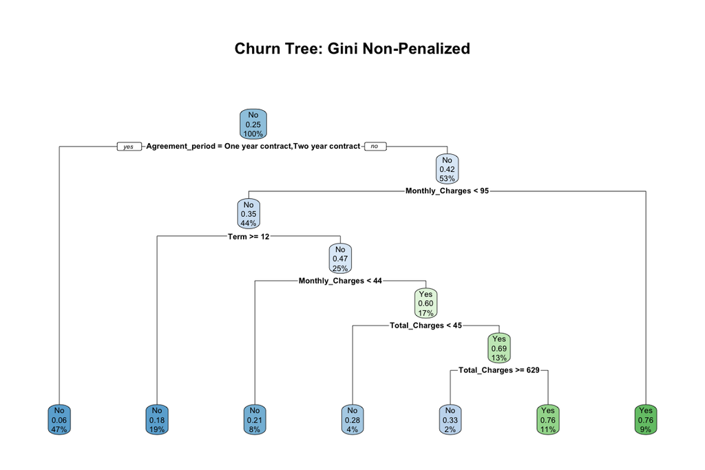

```r
gini.tree.1.1 <- tree.builder(train_data, 1, 1, "gini")
rpart.plot(gini.tree.1.1, main = "Churn Tree: Gini Non-Penalized")
```

### 3.3.2 Peanalized - False Negative

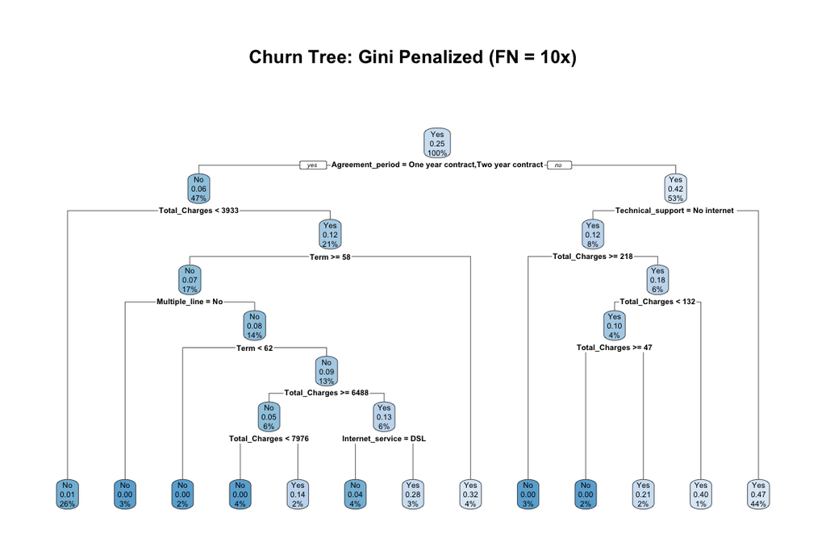

```r
# Penalized: FN = 10 times FP
gini.tree.1.10 <- tree.builder(train_data, 1, 10, "gini")

# Plot
rpart.plot(gini.tree.1.10, main = "Churn Tree: Gini Penalized (FN = 10x)")
```

### 3.3.3 Peanalize - False Positive

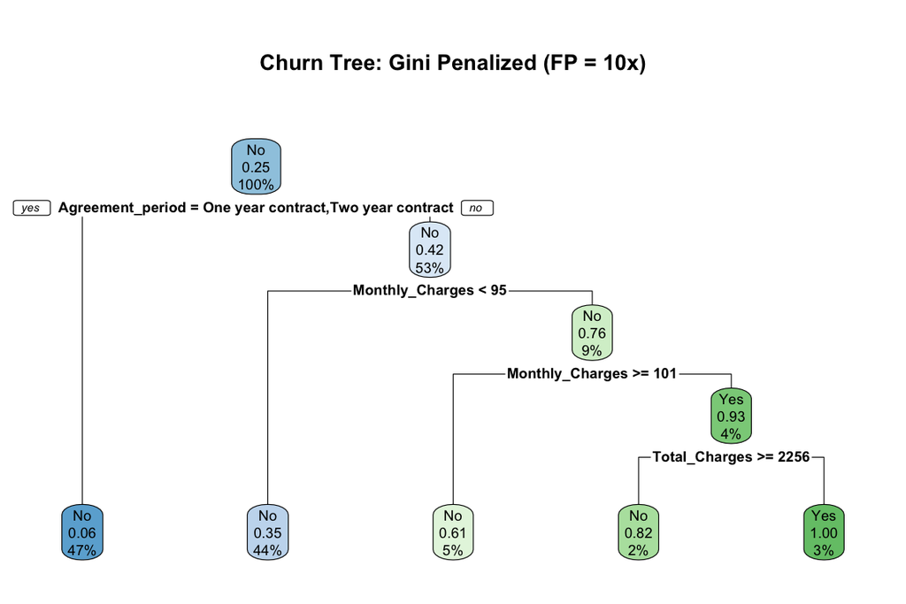

```r
# Penalized: FP = 10 times FN
gini.tree.10.1 <- tree.builder(train_data, 10, 1, "gini")

rpart.plot(gini.tree.10.1, main = "Churn Tree: Gini Penalized (FP = 10x)")
```

That is the third and final decision tree model we will be looking at for this data set. The next section will go into assessing both the candidate models from last weeks assignment and the three candidate models from above. This will allow us to determine the best candidate models for each of the three model types.

## 3.4 ROC Analysis

ROC Analysis and AUC will be used to determine which canidate models are the best from the models created over this week and last week. We are going to start with the logistic models, then look at the perceptron models, finishing with the decision trees.

### 3.4.1 Logistic Model

Looking at the results for our logistic models we can see that in terms of ranking the AUC output the stepwise model narrowly beats out the full model which narrowly beats out the reduced model. When selecting final models not only is AUC important but also making sure the model is reduced down if possible. Not only is the stepwise model smaller than the full model and equally sized to the reduced model, it has the highest AUC, which is ideal when selecting a final model. Taking all these factors into consideration, it makes sense to use the stepwise model as the final logistic regression model.

```r
# --- Predictions for each logistic model ---
pred_full    <- predict(fullModel, newdata = test_data, type = "response")
pred_reduced <- predict(reducedModel, newdata = test_data, type = "response")
pred_step    <- predict(stepModel, newdata = test_data, type = "response")

# --- ROC and AUC for each ---
roc_full    <- roc(test_data$Churn, pred_full, levels = c("No", "Yes"))
roc_reduced <- roc(test_data$Churn, pred_reduced, levels = c("No", "Yes"))
roc_step    <- roc(test_data$Churn, pred_step, levels = c("No", "Yes"))

auc_full    <- auc(roc_full)
auc_reduced <- auc(roc_reduced)
auc_step    <- auc(roc_step)

# --- AUC summary table ---
AUC_logistic <- data.frame(
  Model = c("Full Logistic", "Reduced Logistic", "Stepwise Logistic"),
  AUC = c(auc_full, auc_reduced, auc_step)
)
AUC_logistic
```

```
              Model       AUC
1     Full Logistic 0.8042817
2  Reduced Logistic 0.7915127
3 Stepwise Logistic 0.8081395
```

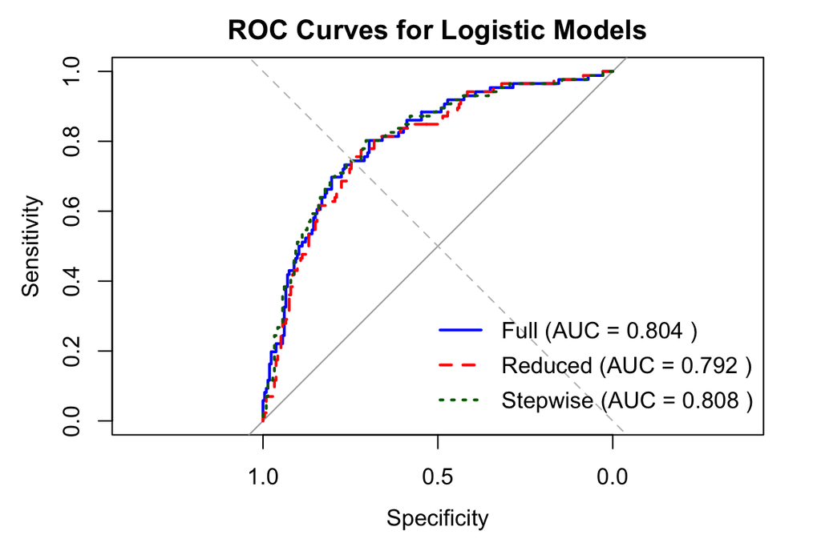

```r
plot(roc_full, col = "blue", lwd = 2, main = "ROC Curves for Logistic Models")
plot(roc_reduced, col = "red", lwd = 2, lty = 2, add = TRUE)
plot(roc_step, col = "darkgreen", lwd = 2, lty = 3, add = TRUE)
abline(0, 1, lty = 2, col = "gray")

legend("bottomright",
       legend = c(
         paste("Full (AUC =", round(auc_full, 3), ")"),
         paste("Reduced (AUC =", round(auc_reduced, 3), ")"),
         paste("Stepwise (AUC =", round(auc_step, 3), ")")
       ),
       col = c("blue", "red", "darkgreen"), lty = 1:3, lwd = 2, bty = "n")
```

### 3.4.2 Perceptron Model

Moving onto the perceptron models we only have two to look at, the full and reduced model. When looking at this output we see something that is not common, a perfect 1.0 AUC and a right angle. While in typical scenarios a AUC of 1 is ideal, the likelihood of this actually happening is close to impossible. Some trouble shooting went on behind the scenes in an attemt to correct this and get a more accurate AUC but it was unsuccessful. It seems to be some kind of issue with data leakage that is unable to be fixed. Considering this unnatural AUC value and the full model being so complex it is typically not ideal, it makes sense not to move forward with this model. Thankfully, the reduced model does still have a good AUC value and it will work as the final perceptron model moving forward.

```r
# Split churn_nn_dummy into train/test
set.seed(123)
train_index <- sample(1:nrow(churn_nn_dummy), 0.7 * nrow(churn_nn_dummy))
train_nn <- churn_nn_dummy[train_index, ]
test_nn  <- churn_nn_dummy[-train_index, ]

# Variables for full and reduced perceptron
NN_vars_full <- setdiff(colnames(train_nn), "Churn_num")
NN_vars_reduced <- c("Term_scale", "Total_Charges_scale",
                     "Agreement_periodOne.year.contract",
                     "Agreement_periodTwo.year.contract")

# Train full perceptron
NN_full <- neuralnet(as.formula(paste("Churn_num ~", paste(NN_vars_full, collapse="+"))),
                     data = train_nn, hidden = 1,
                     act.fct = "logistic", linear.output = FALSE)

# Train reduced perceptron
NN_reduced <- neuralnet(as.formula(paste("Churn_num ~", paste(NN_vars_reduced, collapse="+"))),
                        data = train_nn, hidden = 1,
                        act.fct = "logistic", linear.output = FALSE)

# Predictions on test set
NN_full_pred    <- compute(NN_full, test_nn[, NN_vars_full])$net.result
NN_reduced_pred <- compute(NN_reduced, test_nn[, NN_vars_reduced])$net.result

# ROC and AUC
roc_NN_full    <- roc(test_nn$Churn_num, NN_full_pred)
roc_NN_reduced <- roc(test_nn$Churn_num, NN_reduced_pred)

auc_NN_full    <- auc(roc_NN_full)
auc_NN_reduced <- auc(roc_NN_reduced)

# --- AUC summary table ---
AUC_perceptron <- data.frame(
  Model = c("Full Perceptron", "Reduced Perceptron"),
  AUC = c(auc_NN_full, auc_NN_reduced)
)
AUC_perceptron
```

```
               Model       AUC
1    Full Perceptron 1.0000000
2 Reduced Perceptron 0.7410074
```

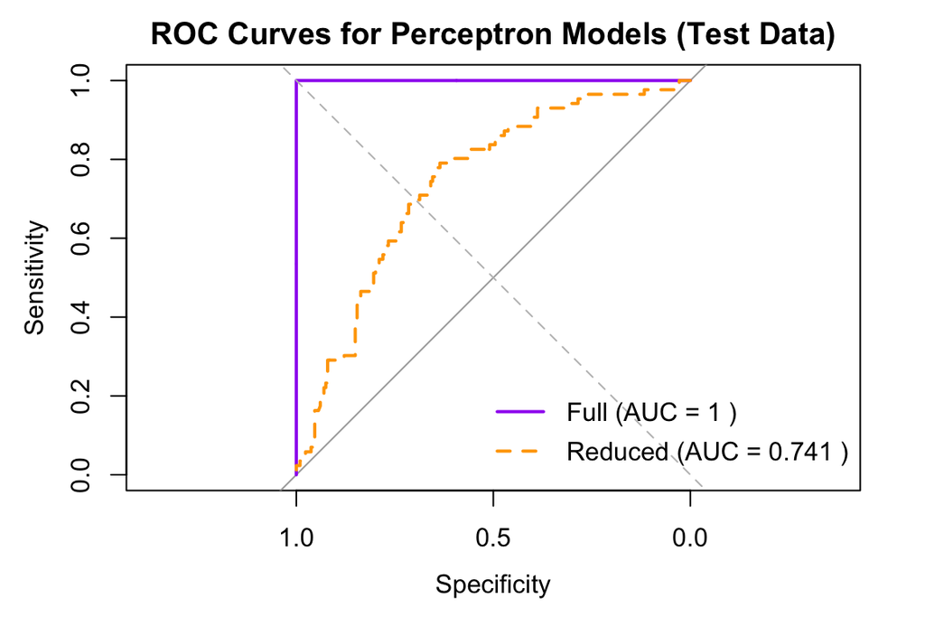

```r
# --- Plot ROC curves ---
plot(roc_NN_full, col = "purple", lwd = 2, main = "ROC Curves for Perceptron Models (Test Data)")
plot(roc_NN_reduced, col = "orange", lwd = 2, lty = 2, add = TRUE)
abline(0, 1, lty = 2, col = "gray")

legend("bottomright",
       legend = c(
         paste("Full (AUC =", round(auc_NN_full, 3), ")"),
         paste("Reduced (AUC =", round(auc_NN_reduced, 3), ")")
       ),
       col = c("purple", "orange"), lty = 1:2, lwd = 2, bty = "n")
```

### 3.4.3 Decision Tree Model

Finally it is time to look at the decision tree models. This final model decision is slightly different because while we have 3 models we will be doing 6 ROC AUC comparisons. This is because each of the three models has a gini and info version. At their core the gini and info versions of a model are the same, they just use slightly different criteria when creating the tree. Looking at the output the model with the best AUC out of the 6 is the info false negative model, represented on the graph as info.1.10. This means the false negative model will be the final decision tree model for the future analysis.

```r
SenSpe <- function(in.data, fp, fn, purity){
  cutoff = seq(0, 1, length = 20)
  model = tree.builder(in.data, fp, fn, purity)
  pred = predict(model, newdata = in.data, type = "prob")

  # Initialize matrix for Sensitivity and Specificity
  senspe.mtx = matrix(0, ncol = length(cutoff), nrow = 2)

  for (i in 1:length(cutoff)){
    pred.out = ifelse(pred[,"Yes"] >= cutoff[i], "Yes", "No")
    TP = sum(pred.out == "Yes" & in.data$Churn == "Yes")
    TN = sum(pred.out == "No"  & in.data$Churn == "No")
    FP = sum(pred.out == "Yes" & in.data$Churn == "No")
    FN = sum(pred.out == "No"  & in.data$Churn == "Yes")

    senspe.mtx[1,i] = TP / (TP + FN)  # Sensitivity
    senspe.mtx[2,i] = TN / (TN + FP)  # Specificity
  }

  # ROC and AUC calculation
  ROCobj <- roc(in.data$Churn == "Yes", pred[,"Yes"])
  AUC = auc(ROCobj)

  list(senspe.mtx = senspe.mtx, AUC = round(AUC, 3))
}
```

```r
# Non-penalized
giniROC11   = SenSpe(in.data = train_data, fp = 1, fn = 1, purity = "gini")
infoROC11   = SenSpe(in.data = train_data, fp = 1, fn = 1, purity = "information")

# Penalize false negatives (customers leaving)
giniROC110  = SenSpe(in.data = train_data, fp = 1, fn = 10, purity = "gini")
infoROC110  = SenSpe(in.data = train_data, fp = 1, fn = 10, purity = "information")

# Penalize false positives (customers incorrectly flagged as leaving)
giniROC101  = SenSpe(in.data = train_data, fp = 10, fn = 1, purity = "gini")
infoROC101  = SenSpe(in.data = train_data, fp = 10, fn = 1, purity = "information")
```

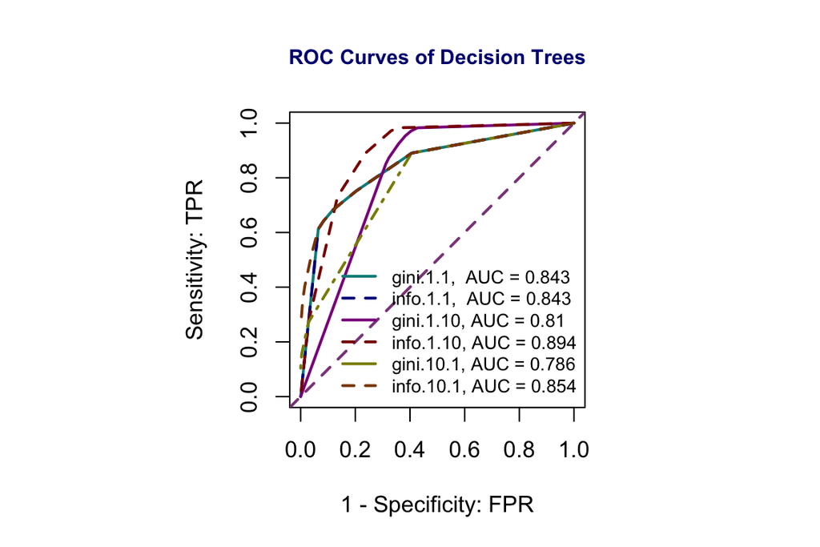

```r
par(pty = "s")  # square plot
colors = c("#008B8B", "#00008B", "#8B008B", "#8B0000", "#8B8B00", "#8B4500")

plot(1 - giniROC11$senspe.mtx[2,], giniROC11$senspe.mtx[1,],
     type = "l",
     xlim = c(0, 1),
     ylim = c(0, 1),
     xlab = "1 - Specificity: FPR",
     ylab = "Sensitivity: TPR",
     col = colors[1],
     lwd = 2,
     main = "ROC Curves of Decision Trees",
     cex.main = 0.9,
     col.main = "navy")

abline(0, 1, lty = 2, col = "orchid4", lwd = 2)

lines(1 - infoROC11$senspe.mtx[2,], infoROC11$senspe.mtx[1,],
      col = colors[2], lwd = 2, lty = 2)
lines(1 - giniROC110$senspe.mtx[2,], giniROC110$senspe.mtx[1,],
      col = colors[3], lwd = 2)
lines(1 - infoROC110$senspe.mtx[2,], infoROC110$senspe.mtx[1,],
      col = colors[4], lwd = 2, lty = 2)
lines(1 - giniROC101$senspe.mtx[2,], giniROC101$senspe.mtx[1,],
      col = colors[5], lwd = 2, lty = 4)
lines(1 - infoROC101$senspe.mtx[2,], infoROC101$senspe.mtx[1,],
      col = colors[6], lwd = 2, lty = 2)

legend("bottomright",
       c(paste("gini.1.1,  AUC =", giniROC11$AUC),
         paste("info.1.1,  AUC =", infoROC11$AUC),
         paste("gini.1.10, AUC =", giniROC110$AUC),
         paste("info.1.10, AUC =", infoROC110$AUC),
         paste("gini.10.1, AUC =", giniROC101$AUC),
         paste("info.10.1, AUC =", infoROC101$AUC)),
       col = colors,
       lty = rep(1:2, 3),
       lwd = rep(2, 6),
       cex = 0.8,
       bty = "n")
```

```r
# Create AUC summary table
AUC_results <- data.frame(
  Model = c("Gini (1,1)", "Gini (1,10)", "Gini (10,1)",
            "Info (1,1)", "Info (1,10)", "Info (10,1)"),
  AUC = c(giniROC11$AUC, giniROC110$AUC, giniROC101$AUC,
          infoROC11$AUC, infoROC110$AUC, infoROC101$AUC)
)

AUC_results
```

```
        Model   AUC
1  Gini (1,1) 0.843
2 Gini (1,10) 0.810
3 Gini (10,1) 0.786
4  Info (1,1) 0.843
5 Info (1,10) 0.894
6 Info (10,1) 0.854
```

The selection of each model types final and optimal model ends the ROC analysis. In order to determine the overall best model from the three final models the bagging AUC method will be used, which will be done in the next section.